# Technical Appendix Midterm

Mark Russeff & Loi Pham

February 18, 2019

```r
# Course: BUAN 5210
# Title: Technical Appendix Midterm
# Purpose: Midterm Project
# Date: February 14, 2019
# Authors: Mark Russeff & Loi Pham
```

```r
# Load packages
library(tidyverse)
library(GGally)
library(gridExtra)
library(kableExtra)
library(scales)
library(cowplot)
```

# 1 Load and Review Data

```r
#Load data
mtp_product <- read.csv("mtp_product_data.csv")
mtp_sales <- read.csv("mtp_sales_data.csv")

#Check structure of the data
str(mtp_product)
```

```
## 'data.frame':    114 obs. of  5 variables:
##  $ UPC    : Factor w/ 114 levels "00-01-16000-11653",..: 1 2 3 4 5 6 7 8 9 10 ...
##  $ brand  : Factor w/ 15 levels "GENERAL MILLS CHEERIOS",..: 2 1 2 5 1 3 2 5 2 5 ...
##  $ flavor : Factor w/ 5 levels "CINNAMON TOAST",..: 1 5 1 5 5 2 1 5 1 5 ...
##  $ volume : num  0.06 0.04 0.12 0.11 0.08 0.89 0.98 0.87 0.8 1.5 ...
##  $ package: Factor w/ 2 levels "BOX","CUP": 1 1 2 2 2 1 1 1 1 1 ...
```

```r
str(mtp_sales)
```

```
## 'data.frame':    21850 obs. of  7 variables:
##  $ UPC    : Factor w/ 114 levels "01.16000.11653",..: 1 1 1 2 2 2 3 3 3 3 ...
##  $ iri_key: int  644347 248741 535806 675634 205272 248741 932600 278738 660222 644937 ...
##  $ week   : int  6 5 11 11 13 14 39 35 45 5 ...
##  $ units  : int  5 2 3 2 8 5 6 1 4 14 ...
##  $ price  : num  0.5 0.5 0.5 0.5 0.5 0.5 1.09 1.59 1.59 1 ...
##  $ promo  : int  0 0 0 0 0 0 0 0 0 0 ...
##  $ ad     : Factor w/ 3 levels "A","B","NONE": 1 3 3 3 3 3 3 3 3 3 ...
```

## 1.1 Join the Data Sets

```r
#Modify strings in UPC for join
mtp_product$UPC <- str_replace(mtp_product$UPC,"00-","")
mtp_sales$UPC <- str_replace_all(mtp_sales$UPC,"[.]","-")

#Join data frames into one by UPC
mtp <- mtp_sales %>%
  full_join(mtp_product, by = "UPC")
```

## 1.2 Clean and Organize the Joined Data

```r
companies <- c("GENERAL MILLS", "KELLOGGS", "POST")

mtp <- mtp %>%
  mutate(company = brand, cereal = brand)

for (pattern in companies) {
  mtp <- mtp %>%
    mutate(company = if_else(str_detect(company, pattern),
                             pattern, as.character(company)),
           cereal = str_replace(cereal, pattern, ""),
           cereal = str_replace(cereal, "TST CR", "TOAST CRUNCH"))
}

mtp <- mtp %>%
  mutate(company = as.factor(str_to_title(company)),
         company = str_trim(str_replace(company, " ", "_")),
         cereal = as.factor(str_trim(str_to_title(cereal))),
         promo = as.factor(promo),

         revenue = price * units,
         price_volume = price / volume) %>%
  select(company, cereal, price, units, volume, revenue, price_volume, promo, ad, package, week, iri_key)
```

# 2 Univariate non-graphical

## 2.1 Categorical data - summary

```r
# Inspect descriptive statistics of data
summary(mtp)
```

```
##    company                            cereal          price
##  Length:21850       Frosted Flakes       : 2295   Min.   :0.250
##  Class :character   Froot Loops          : 2192   1st Qu.:3.190
##  Mode  :character   Cinnamon Toast Crunch: 1834   Median :3.790
##                     Lucky Charms         : 1681   Mean   :3.763
##                     Frosted Mini Wheats  : 1574   3rd Qu.:4.390
##                     Cheerios             : 1458   Max.   :9.990
##                     (Other)              :10816
##      units            volume         revenue        price_volume
##  Min.   : 1.000   Min.   :0.040   Min.   :  0.48   Min.   : 0.8867
##  1st Qu.: 3.000   1st Qu.:0.750   1st Qu.: 11.80   1st Qu.: 3.1048
##  Median : 7.000   Median :1.060   Median : 24.50   Median : 3.8639
##  Mean   : 8.579   Mean   :1.016   Mean   : 31.01   Mean   : 4.1449
##  3rd Qu.:12.000   3rd Qu.:1.120   3rd Qu.: 44.09   3rd Qu.: 4.7308
##  Max.   :28.000   Max.   :4.000   Max.   :155.48   Max.   :21.8750
##
##  promo        ad        package          week          iri_key
##  0:17305   A   : 1456   BOX:21306   Min.   : 1.00   Min.   : 200171
##  1: 4545   B   : 1061   CUP:  544   1st Qu.:14.00   1st Qu.: 241553
##            NONE:19333               Median :27.00   Median : 273720
##                                     Mean   :26.62   Mean   : 454405
##                                     3rd Qu.:40.00   3rd Qu.: 648547
##                                     Max.   :52.00   Max.   :8057418
##
```

**Observations on the data**

- Kelloggs sells the most, followed by General Mills and Post.
- Kelloggs Frosted Flakes and Froot Loops are the most popular cereals.
- Cinnamon Toast Crunch is General Mills’ most popular cerearl.
- Price has a tight interquartile range but a very low min and a high max.
- Revenue is skewed due to some very large numbers.
- Because it is calculated from price, price per volume also has a tight interquartile range and high min/max values.
- Roughly 20% of the time there is an in-store promo.
- Only about 11.5% of the time are there ads being run.
- Ads and Promos make up a small percentage of total sales transactions.

## 2.2 Categorical data - tabulation

### 2.2.1 Company

```r
#Table of data by company.
mtp %>%
  group_by(company) %>%
  summarise(count = n(),
  mean_revenue = mean(revenue),
  mean_price = mean(price),
  mean_price_vol = mean(price_volume),
  mean_units = mean(units)) %>%
  arrange(desc(mean_revenue)) %>%
  kable() %>%
  kable_styling(bootstrap_options = c("striped", "hover", "condensed", "responsive"))
```

| company | count | mean_revenue | mean_price | mean_price_vol | mean_units |
| --- | --- | --- | --- | --- | --- |
| General_Mills | 7189 | 35.70587 | 3.861234 | 4.529221 | 9.600362 |
| Kelloggs | 12183 | 29.92518 | 3.723417 | 4.138897 | 8.414348 |
| Post | 2478 | 22.73956 | 3.676731 | 3.059736 | 6.424939 |

- Kelloggs has the highest number of sales but General Mills has the highest average revenue.
- It looks like General Mills may have more pricing power in the market.

### 2.2.2 Cereal

```r
#Table of data by cereal
mtp %>%
  group_by(company, cereal) %>%
  summarise(count = n(),
  mean_revenue = mean(revenue),
  mean_price = mean(price),
  mean_price_vol = mean(price_volume),
  mean_units = mean(units)) %>%
  arrange(desc(mean_revenue)) %>%
  kable() %>%
  kable_styling(bootstrap_options = c("striped", "hover", "condensed", "responsive"))
```

| company | cereal | count | mean_revenue | mean_price | mean_price_vol | mean_units |
| --- | --- | --- | --- | --- | --- | --- |
| General_Mills | Cheerios | 1458 | 51.19142 | 3.631139 | 4.901994 | 14.012346 |
| Kelloggs | Raisin Bran | 1266 | 37.01339 | 3.773175 | 2.662241 | 10.184834 |
| General_Mills | Lucky Charms | 1681 | 36.21869 | 4.230851 | 4.610167 | 9.118977 |
| Kelloggs | Special K | 1391 | 35.36902 | 3.995722 | 5.089381 | 9.171100 |
| Kelloggs | Frosted Mini Wheats | 1574 | 35.14232 | 3.747694 | 3.222841 | 9.581321 |
| Kelloggs | Rice Krispies | 1450 | 35.00250 | 3.670738 | 4.684190 | 9.949655 |
| General_Mills | Cinnamon Toast Crunch | 1834 | 34.15395 | 4.040954 | 4.056746 | 8.743184 |
| Kelloggs | Frosted Flakes | 2295 | 33.35530 | 3.743643 | 3.650653 | 9.461002 |
| General_Mills | Kix | 1196 | 26.98423 | 3.674348 | 5.027739 | 7.591973 |
| Post | Grape Nuts | 1289 | 26.03881 | 3.822033 | 2.687656 | 7.072149 |
| General_Mills | Cocoa Puffs | 1020 | 25.74243 | 3.476980 | 4.127962 | 7.983333 |
| Kelloggs | Smart Start | 1134 | 22.71065 | 3.829762 | 3.745839 | 6.295414 |
| Kelloggs | Froot Loops | 2192 | 20.62031 | 3.546793 | 4.955864 | 6.351734 |
| Post | Shredded Wheat | 1189 | 19.16284 | 3.519209 | 3.463109 | 5.723297 |
| Kelloggs | Cocoa Krispies | 881 | 16.96889 | 3.515187 | 5.244427 | 5.196368 |

- General Mills strongest cereal brand in terms of average revenue is Cheerios.
- This is primarily from a high average units combined with a higher price per oz.
- Suggesting that Cheerios come in a smaller (lower volume) box or cup, so customers buy more units.
- In terms of average revenue General Mills Cereals are performing well amoung their peers.

### 2.2.3 Ad

```r
mtp %>%
  group_by(company, ad) %>%
  summarise(count = n(),
  mean_revenue = mean(revenue),
  mean_price = mean(price),
  mean_price_vol = mean(price_volume),
  mean_units = mean(units)) %>%
  arrange(desc(mean_revenue)) %>%
  kable() %>%
  kable_styling(bootstrap_options = c("striped", "hover", "condensed", "responsive"))
```

| company | ad | count | mean_revenue | mean_price | mean_price_vol | mean_units |
| --- | --- | --- | --- | --- | --- | --- |
| General_Mills | A | 442 | 37.65007 | 3.372376 | 4.051076 | 11.823529 |
| General_Mills | NONE | 6475 | 35.59291 | 3.925404 | 4.587407 | 9.351197 |
| General_Mills | B | 272 | 35.23559 | 3.128052 | 3.921082 | 11.919118 |
| Kelloggs | B | 664 | 34.60092 | 3.206446 | 3.629184 | 11.371988 |
| Kelloggs | A | 903 | 31.94854 | 3.309092 | 3.506158 | 10.312292 |
| Kelloggs | NONE | 10616 | 29.46062 | 3.790995 | 4.224598 | 8.067916 |
| Post | B | 125 | 25.20736 | 2.948560 | 2.609814 | 9.304000 |
| Post | A | 111 | 24.78640 | 2.771622 | 2.527678 | 9.612613 |
| Post | NONE | 2242 | 22.50064 | 3.762141 | 3.111162 | 6.106601 |

- In terms of average revenue General Mills does better than their peers whether implimenting an Ad or not.
- Interestingly, no ad performs better than having just a medium/small ad.
- The medium/small ads for General Mills are underperforming compared to their peers.
- This could be due to the fact that the average price and average price per oz are considerably lower with a B ad.

### 2.2.4 Promo

```r
mtp %>%
  group_by(company, promo) %>%
  summarise(count = n(),
  mean_revenue = mean(revenue),
  mean_price = mean(price),
  mean_price_vol = mean(price_volume),
  mean_units = mean(units)) %>%
  arrange(desc(mean_revenue)) %>%
  kable() %>%
  kable_styling(bootstrap_options = c("striped", "hover", "condensed", "responsive"))
```

| company | promo | count | mean_revenue | mean_price | mean_price_vol | mean_units |
| --- | --- | --- | --- | --- | --- | --- |
| General_Mills | 1 | 1280 | 36.16737 | 2.961242 | 3.759158 | 12.471094 |
| General_Mills | 0 | 5909 | 35.60590 | 4.056189 | 4.696031 | 8.978507 |
| Kelloggs | 1 | 2713 | 32.56013 | 2.977468 | 3.510093 | 11.157022 |
| Kelloggs | 0 | 9470 | 29.17031 | 3.937119 | 4.319039 | 7.628617 |
| Post | 1 | 552 | 23.76051 | 2.954149 | 2.502224 | 8.436594 |
| Post | 0 | 1926 | 22.44696 | 3.883827 | 3.219521 | 5.848390 |

- In terms of average revenue General Mills is performing well compared to their peers whether they are running an instore promo or not.

### 2.2.5 Ad and Promo

```r
mtp %>%
  group_by(company, ad, promo) %>%
  summarise(count = n(),
  mean_revenue = mean(revenue),
  mean_price = mean(price),
  mean_price_vol = mean(price_volume),
  mean_units = mean(units)) %>%
  arrange(desc(mean_revenue)) %>%
  kable() %>%
  kable_styling(bootstrap_options = c("striped", "hover", "condensed", "responsive"))
```

| company | ad | promo | count | mean_revenue | mean_price | mean_price_vol | mean_units |
| --- | --- | --- | --- | --- | --- | --- | --- |
| General_Mills | A | 1 | 224 | 38.15759 | 2.785089 | 3.501044 | 13.982143 |
| Kelloggs | B | 1 | 395 | 37.51446 | 2.841924 | 3.142544 | 13.250633 |
| General_Mills | A | 0 | 218 | 37.12858 | 3.975826 | 4.616247 | 9.605505 |
| General_Mills | B | 0 | 100 | 37.12150 | 4.077700 | 4.666396 | 9.380000 |
| General_Mills | NONE | 1 | 884 | 36.05770 | 3.080848 | 3.877368 | 11.908371 |
| General_Mills | NONE | 0 | 5591 | 35.51942 | 4.058938 | 4.699672 | 8.946879 |
| General_Mills | B | 1 | 172 | 34.13913 | 2.575930 | 3.487760 | 13.395349 |
| Kelloggs | A | 1 | 458 | 33.99880 | 2.691594 | 2.883068 | 12.759825 |
| Kelloggs | NONE | 1 | 1860 | 31.15375 | 3.076645 | 3.742544 | 10.317742 |
| Kelloggs | B | 0 | 269 | 30.32268 | 3.741710 | 4.343766 | 8.613383 |
| Kelloggs | A | 0 | 445 | 29.83838 | 3.944629 | 4.147451 | 7.793258 |
| Kelloggs | NONE | 0 | 8756 | 29.10096 | 3.942741 | 4.326999 | 7.589995 |
| Post | B | 1 | 92 | 26.67272 | 2.629891 | 2.262837 | 10.500000 |
| Post | A | 1 | 91 | 25.37527 | 2.504945 | 2.210360 | 10.516483 |
| Post | NONE | 1 | 369 | 22.63621 | 3.145772 | 2.633886 | 7.409214 |
| Post | NONE | 0 | 1873 | 22.47393 | 3.883572 | 3.205191 | 5.849973 |
| Post | A | 0 | 20 | 22.10700 | 3.985000 | 3.971475 | 5.500000 |
| Post | B | 0 | 33 | 21.12212 | 3.836970 | 3.577144 | 5.969697 |

- We know that General Mills’ medium/small ads are underperforming.
- The underperfoming ads appear to be only when combined with instore promos.
- For Kellogs and Post B ads with instore promos are thier best perfoming combination, yet not for General Mills.
- **Why are Medium/Small Ads not woking in combination with instore promotions?**

# 3 Univariate graphical: categorical

## 3.1 Company

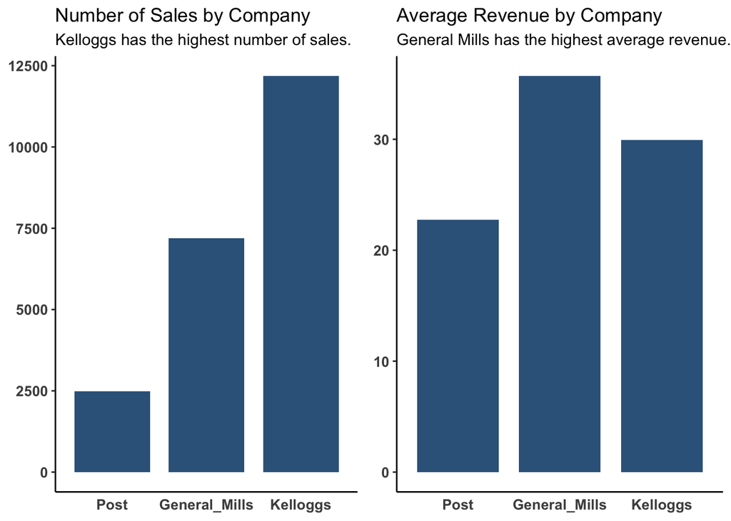

```r
grid.arrange(
  #Graph Companies by number of sales.
   mtp %>%
    group_by(company) %>%
    summarise(count = n()) %>%
    ggplot(aes(x = reorder(company, count),
             y = count)) +
    geom_bar(stat = "identity", fill = "steelblue4",
             width = 0.8) +
    theme(panel.grid.major = element_blank(),
        panel.grid.minor = element_blank()) +
    ggtitle("Number of Sales by Company",
          subtitle = "Kelloggs has the highest number of sales.") +
    theme_classic() +
  theme(axis.text = element_text(face = "bold", size = 10),
        axis.title = element_blank(),
        axis.ticks.x = element_blank(),
        legend.title = element_text(face = "bold")) ,

  #Graph Companies by mean revenue.
  mtp %>%
    group_by(company) %>%
    summarise(mean_revenue = mean(revenue), count = n()) %>%
    ggplot(aes(x = reorder(company, count),
             y = mean_revenue)) +
    geom_bar(stat = "identity", fill = "steelblue4",
             width = 0.8) +
    theme(panel.grid.major = element_blank(),
        panel.grid.minor = element_blank()) +
    ggtitle("Average Revenue by Company",
          subtitle = "General Mills has the highest average revenue.") +
    theme_classic() +
    theme(axis.text = element_text(face = "bold", size = 10),
        axis.title = element_blank(),
        axis.ticks.x = element_blank(),
        legend.title = element_text(face = "bold")) ,

ncol = 2
)
```

- We see that Kelloggs leads the idustry in number of sales but General Mills has a higher average revenue.
- This is good for General Mills, indicating that there is possible room to grow.
- Post lags in both sales and mean revenue.

## 3.2 Cereal

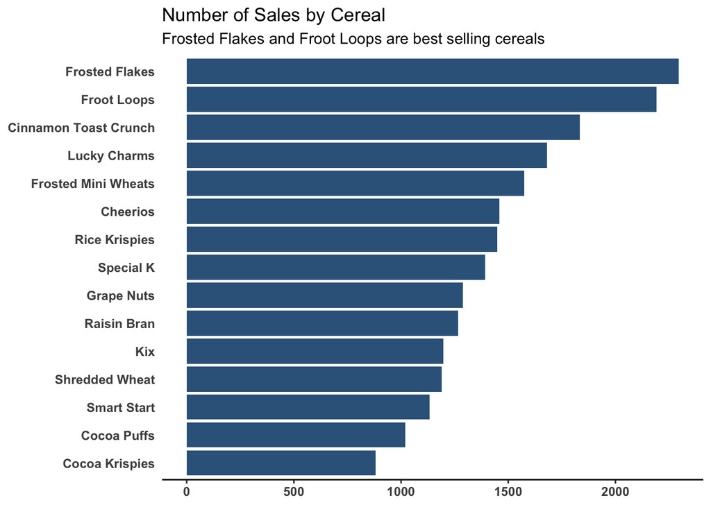

```r
#Graphing the most popular cereal brands by number of sales.
mtp %>%
    group_by(cereal) %>%
    summarise(count = n()) %>%
    ggplot(aes(x = reorder(cereal, count),
             y = count)) +
    geom_bar(stat = "identity", fill = "steelblue4") +
    theme(panel.grid.major = element_blank(),
        panel.grid.minor = element_blank()) +
    coord_flip() +
    xlab("Cereal") +
    ylab("") +
    ggtitle("Number of Sales by Cereal",
          subtitle = "Frosted Flakes and Froot Loops are best selling cereals") +
  theme_classic() +
  theme(axis.text = element_text(face = "bold", size = 9),
        axis.title.x = element_blank(),
        axis.title = element_blank(),
        axis.line.y = element_blank(),
        axis.ticks.y = element_blank(),
        legend.title = element_text(face = "bold"))
```

- Bassed on number of sales, Frosted Flakes and Froot Loops (both Kelloggs cereals) are the most popular cereal brands.
- For the Genereal Mills brands Cinnamon Toast Crunch is the most popular.

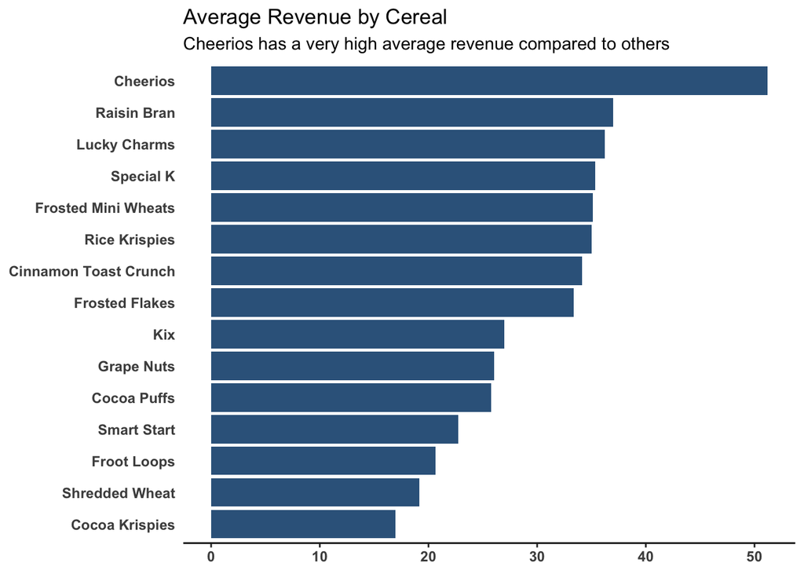

```r
#Graphing mean revenue by cereal brand.
mtp %>%
    group_by(cereal) %>%
    summarise(mean_revenue = mean(revenue)) %>%
    ggplot(aes(x = reorder(cereal, mean_revenue),
             y = mean_revenue)) +
    geom_bar(stat = "identity", fill = "steelblue4") +
    theme(panel.grid.major = element_blank(),
        panel.grid.minor = element_blank()) +
    coord_flip() +
    xlab("Cereal") +
    ylab("") +
    ggtitle("Average Revenue by Cereal",
          subtitle = "Cheerios has a very high average revenue compared to others") +
  theme_classic() +
  theme(axis.text = element_text(face = "bold", size = 9),
        axis.title.x = element_blank(),
        axis.title = element_blank(),
        axis.line.y = element_blank(),
        axis.ticks.y = element_blank(),
        legend.title = element_text(face = "bold"))
```

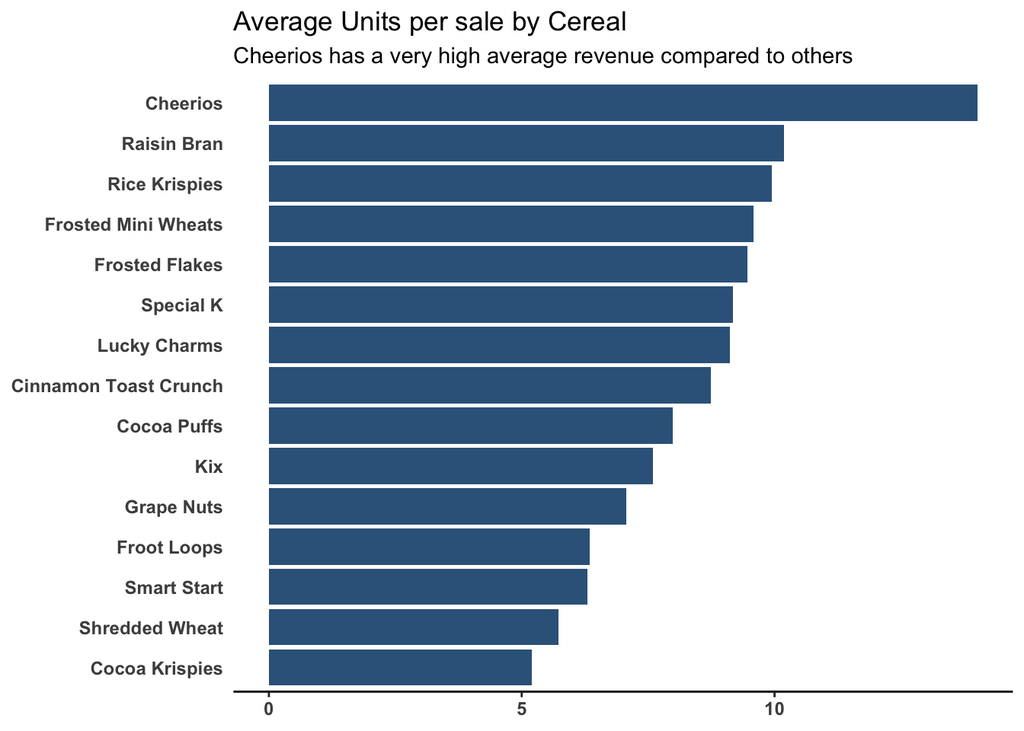

```r
#Graphing mean units by cereal
mtp %>%
    group_by(cereal) %>%
    summarise(mean_units = mean(units)) %>%
    ggplot(aes(x = reorder(cereal, mean_units),
             y = mean_units)) +
    geom_bar(stat = "identity", fill = "steelblue4") +
    theme(panel.grid.major = element_blank(),
        panel.grid.minor = element_blank()) +
    coord_flip() +
    xlab("Cereal") +
    ylab("") +
    ggtitle("Average Units per sale by Cereal",
          subtitle = "Cheerios has a very high average revenue compared to others") +
  theme_classic() +
  theme(axis.text = element_text(face = "bold", size = 9),
        axis.title.x = element_blank(),
        axis.title = element_blank(),
        axis.line.y = element_blank(),
        axis.ticks.y = element_blank(),
        legend.title = element_text(face = "bold"))
```

- Graphically we can see what we intuitively know; that high mean units are closely related to high mean revenue.
- This relationship makes sense because units is part of the revenue calculation.
- Does higher mean units or higher mean price have the most significant affect on mean revenue?
- Cheerios has the highest average revenue per sale and highest units per sale. (General Mills brand).
- This likely accounts for much of General Mills success as a company at generating substantial revenues.

## 3.3 Ad

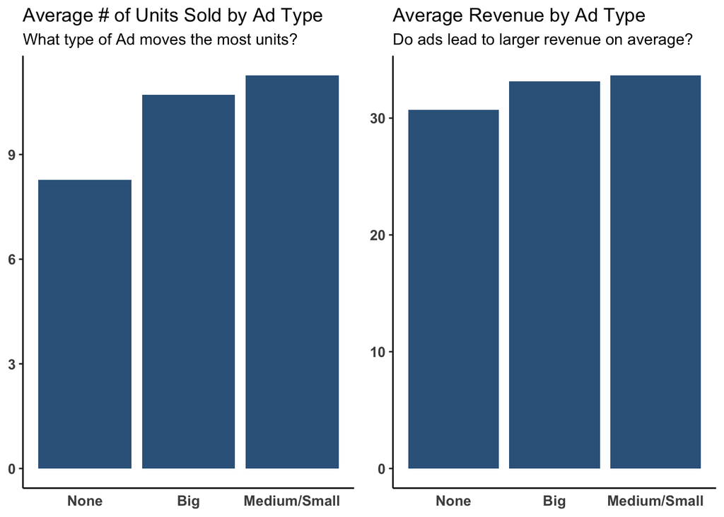

```r
#Graphing mean units and mean revenue by ad, examining ad effectiveness.
grid.arrange(
  mtp %>%
    mutate(ad = if_else(ad == "A", "Big", if_else(ad == "B", "Medium/Small", "None"))) %>%
    group_by(ad) %>%
    summarise(mean_units = mean(units)) %>%
    ggplot(aes(x = reorder(ad, mean_units),
             y = mean_units)) +
    geom_bar(stat = "identity", fill = "steelblue4") +
    theme(panel.grid.major = element_blank(),
        panel.grid.minor = element_blank()) +
    ggtitle("Average # of Units Sold by Ad Type",
          subtitle = "What type of Ad moves the most units?") +
    theme_classic() +
    theme(axis.text = element_text(face = "bold", size = 10),
        axis.title = element_blank(),
        axis.ticks.x = element_blank(),
        legend.title = element_text(face = "bold")) ,

  mtp %>%
    mutate(ad = if_else(ad == "A", "Big", if_else(ad == "B", "Medium/Small", "None"))) %>%
    group_by(ad) %>%
    summarise(mean_revenue = mean(revenue)) %>%
    ggplot(aes(x = reorder(ad, mean_revenue),
             y = mean_revenue)) +
    geom_bar(stat = "identity", fill = "steelblue4") +
    theme(panel.grid.major = element_blank(),
        panel.grid.minor = element_blank()) +
    ggtitle("Average Revenue by Ad Type",
          subtitle = "Do ads lead to larger revenue on average?") +
    theme_classic() +
    theme(axis.text = element_text(face = "bold", size = 10),
        axis.title = element_blank(),
        axis.ticks.x = element_blank(),
        legend.title = element_text(face = "bold")),


ncol = 2
)
```

- Running adds looks to slightly increase the average units sold but have very little affect on average revenue.
- Why are ads not have more effect on mean revenue, while also increasing mean units sold.

## 3.4 Promo

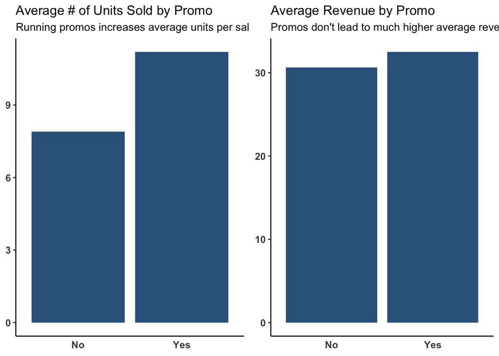

```r
#Graphing mean units and mean revenue for in-store promotions.
grid.arrange(
  mtp %>%
    mutate(promo = if_else(promo == 1, "Yes", "No")) %>%
    group_by(promo) %>%
    summarise(mean_units = mean(units)) %>%
    ggplot(aes(x = reorder(promo, mean_units),
             y = mean_units)) +
    geom_bar(stat = "identity", fill = "steelblue4") +
    theme(panel.grid.major = element_blank(),
        panel.grid.minor = element_blank()) +
    xlab("Instore Promos") +
    ylab("") +
    ggtitle("Average # of Units Sold by Promo",
          subtitle = "Running promos increases average units per sale.") +
    theme_classic() +
    theme(axis.text = element_text(face = "bold", size = 10),
        axis.title = element_blank(),
        axis.ticks.x = element_blank(),
        legend.title = element_text(face = "bold")),

  mtp %>%
    mutate(promo = if_else(promo == 1, "Yes", "No")) %>%
    group_by(promo) %>%
    summarise(mean_revenue = mean(revenue)) %>%
    ggplot(aes(x = reorder(promo, mean_revenue),
             y = mean_revenue)) +
    geom_bar(stat = "identity", fill = "steelblue4") +
    theme(panel.grid.major = element_blank(),
        panel.grid.minor = element_blank()) +
    xlab("Instore Promos") +
    ylab("") +
    ggtitle("Average Revenue by Promo",
          subtitle = "Promos don't lead to much higher average revenue.") +
    theme_classic() +
    theme(axis.text = element_text(face = "bold", size = 10),
        axis.title = element_blank(),
        axis.ticks.x = element_blank(),
        legend.title = element_text(face = "bold")),


ncol = 2
)
```

- Similar as with the ads, instore promos look to slightly increase average units but have very little affect on average revenue.

# 4 Multi-variate graphical: quantitative

## 4.1 Correlations

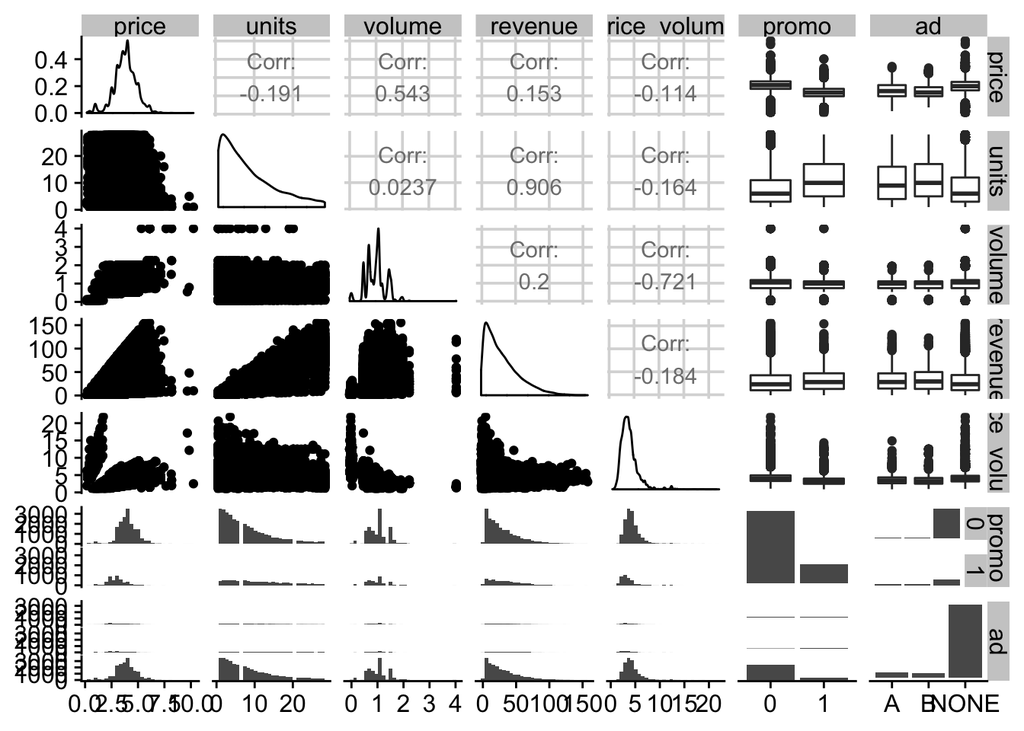

```r
ggpairs(subset(mtp, select = -c(iri_key, package, cereal, company, week)))
```

# 5 Multi-variate graphical: categorical and quantitative

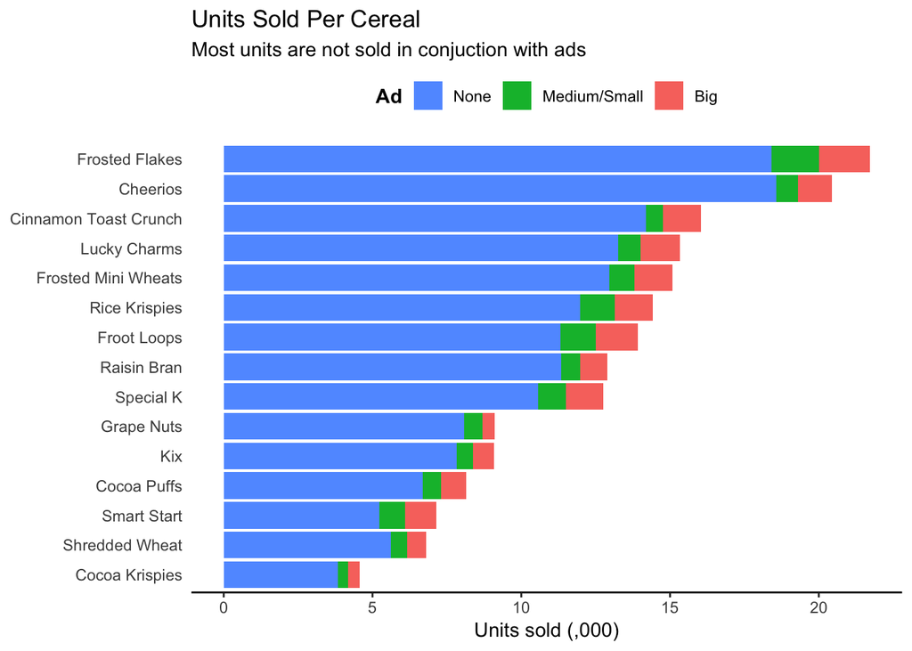

```r
mtp %>%
  mutate(ad = if_else(ad == "A", "Big", if_else(ad == "B", "Medium/Small", "None"))) %>%
  group_by(cereal, ad) %>%
  summarise(units_sold = sum(units) / 1000) %>%
  ggplot(aes(x = reorder(cereal, units_sold), y = units_sold, fill = ad)) +
    geom_bar(stat = "identity") +
    labs(fill = "Ad", y = "Units sold (,000)") +
    coord_flip() +
    guides(fill = guide_legend(reverse = TRUE)) +
    theme_classic() +
    theme(legend.position = "top",
          legend.justification = "center",
          legend.title = element_text(face = "bold"),
          axis.title.y = element_blank(),
          axis.ticks.y = element_blank(),
          axis.line.y = element_blank()) +
    ggtitle("Units Sold Per Cereal",
          subtitle = "Most units are not sold in conjuction with ads")
```

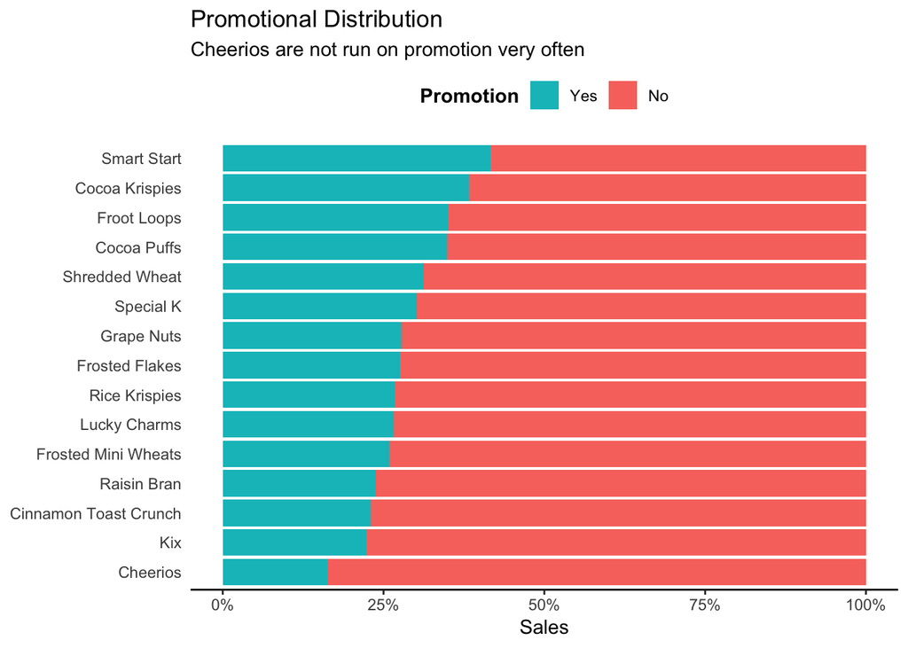

```r
mtp %>%
  group_by(cereal, promo) %>%
  summarise(subtotal = sum(units)) %>%
  group_by(cereal) %>%
  mutate(promo_pct = subtotal / sum(subtotal),
         promo = if_else(promo == 1, "Yes", "No")) %>%
  arrange(promo, promo_pct) %>%
  mutate(brand2 = factor(cereal, levels = filter(., promo == "Yes") %>% .$cereal)) %>%
  ggplot(aes(x = brand2, y = promo_pct, fill = promo)) +
    geom_bar(stat = "identity") +
    labs(fill = "Promotion", y = "Sales") +
    coord_flip() +
    guides(fill = guide_legend(reverse = TRUE)) +
    scale_y_continuous(labels = percent_format(accuracy = 1, suffix = "%")) +
    theme_classic() +
    theme(legend.position = "top",
          legend.justification = "center",
          legend.title = element_text(face = "bold"),
          axis.title.y = element_blank(),
          axis.ticks.y = element_blank(),
          axis.line.y = element_blank()) +
    ggtitle("Promotional Distribution",
          subtitle = "Cheerios are not run on promotion very often")
```

# 6 Research Questions

## 6.1 Question 1: How effective is Genereal Mills’ promotional strategy and what brands can we focus on to improve promotional success?

### 6.1.1 First we examine General Mills’ current promotional strategy compared to the market.

```r
mtp %>%
  filter(promo == 1) %>%
  group_by(company) %>%
  summarise(Count = n(),
  Average_Revenue = mean(revenue),
  Average_Price = mean(price),
  Average_Price_Vol = mean(price_volume),
  Average_Units = mean(units)) %>%
  arrange(desc(Average_Revenue)) %>%
  kable() %>%
  kable_styling(bootstrap_options = c("striped", "hover", "condensed", "responsive")) %>%
  row_spec(1, background = "#e5f5e0")
```

| company | Count | Average_Revenue | Average_Price | Average_Price_Vol | Average_Units |
| --- | --- | --- | --- | --- | --- |
| General_Mills | 1280 | 36.16737 | 2.961242 | 3.759158 | 12.471094 |
| Kelloggs | 2713 | 32.56013 | 2.977468 | 3.510093 | 11.157022 |
| Post | 552 | 23.76051 | 2.954149 | 2.502224 | 8.436594 |

**Null Hypothesis: Revenue is the same across all companies when running instore promotions.**

```r
mtp_hyp1 <- mtp %>%
  filter(promo == 1)

# Is revenue the same across brands?
t.test(mtp_hyp1$revenue[mtp_hyp1$company == "General_Mills"], mtp_hyp1$revenue[mtp_hyp1$company == "Kelloggs"])
```

```
##
##  Welch Two Sample t-test
##
## data:  mtp_hyp1$revenue[mtp_hyp1$company == "General_Mills"] and mtp_hyp1$revenue[mtp_hyp1$company == "Kelloggs"]
## t = 4.6564, df = 2457.2, p-value = 3.389e-06
## alternative hypothesis: true difference in means is not equal to 0
## 95 percent confidence interval:
##  2.088151 5.126334
## sample estimates:
## mean of x mean of y
##  36.16737  32.56013
```

```r
t.test(mtp_hyp1$revenue[mtp_hyp1$company == "General_Mills"], mtp_hyp1$revenue[mtp_hyp1$company == "Post"])
```

```
##
##  Welch Two Sample t-test
##
## data:  mtp_hyp1$revenue[mtp_hyp1$company == "General_Mills"] and mtp_hyp1$revenue[mtp_hyp1$company == "Post"]
## t = 12.188, df = 1282.3, p-value < 2.2e-16
## alternative hypothesis: true difference in means is not equal to 0
## 95 percent confidence interval:
##  10.40984 14.40390
## sample estimates:
## mean of x mean of y
##  36.16737  23.76051
```

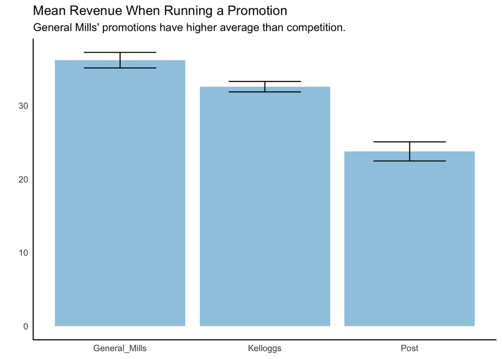

```r
#Graphing the relationship between in-store promotions and revenue across companies.
# 90% CI, get z-value for upper tail, use .95 since is one sided
z <- qnorm(.95)

# Incorporate CI into bar graph of means
mtp_hyp1 %>%
  group_by(company) %>%
  summarise(m = mean(revenue), sd = sd(revenue),
            n = n(), ci = z * sd/sqrt(n)) %>%
  ggplot(aes(x = company, y = m)) +
  geom_bar(stat = "identity", position = "dodge", fill = "#9ecae1") +
  geom_errorbar(aes(ymin = m - ci, ymax = m + ci),
                width = 0.5, position = position_dodge(0.9)) +
  theme_classic() +
  xlab("") +
  ylab("") +
  theme(axis.ticks.x = element_blank(),
          axis.title.x = element_blank(),
          axis.ticks.y = element_blank()) +
  ggtitle("Mean Revenue When Running a Promotion",
          subtitle = "General Mills' promotions have higher average than competition.")
```

**Findings**  
* Based on our sample and the above analysis we can see that General Mills current promotional strategy fairs better than the rest of the market.  
* Examining the t-tests we can reliably say that in terms of mean revenue General Mills’ results are statistically different.  
* Current strategy seems to be working well in comparison to peers.

### 6.1.2 Next we examine General Mills’ family of cereal brands to see if we can improve promotional performance anywhere.

```r
mtp_gm <- mtp %>%
  filter(company == "General_Mills")

#Create a table of General Mills cereals and their mean revenue when an in-store promotion is happening.
mtp_t1 <- mtp_gm %>%
  filter(promo == 1) %>%
  group_by(cereal) %>%
  summarise(Count = n(),
  Average_Revenue = mean(revenue),
  Average_Price = mean(price),
  Average_Price_Vol = mean(price_volume),
  Average_Units = mean(units)) %>%
  arrange(desc(Average_Revenue)) %>%
  kable() %>%
  kable_styling(bootstrap_options = c("striped", "hover", "condensed", "responsive")) %>%
  row_spec(5, background = "#fee0d2")

mtp_t1
```

| cereal | Count | Average_Revenue | Average_Price | Average_Price_Vol | Average_Units |
| --- | --- | --- | --- | --- | --- |
| Cheerios | 218 | 44.62216 | 2.838440 | 4.424103 | 15.24771 |
| Lucky Charms | 315 | 39.91911 | 3.189682 | 3.672455 | 12.95556 |
| Cinnamon Toast Crunch | 297 | 37.02077 | 3.029226 | 3.365002 | 12.41414 |
| Cocoa Puffs | 251 | 30.04474 | 2.779801 | 3.385692 | 11.33865 |
| Kix | 199 | 27.41553 | 2.861558 | 4.227283 | 10.17588 |

Analysis

- When on promotion Cheerios does very well, leading the industry in mean revenue and mean units.
- Both Cocoa Puffs and Kix are struggling with mean revenue both during promotion and not.
- This is likely due to lot mean units, perhaps the price is to high.
- Of interest, the average price per volume is very high for Kix, too small of package?

**Null Hypothesis: Revenue is the same across all General Mills cereals during in-store promotions.**

```r
mtp_hyp2 <- mtp_gm %>%
  filter(promo == 1)

# Is mean revenue the same across all General Mills' brands?

t.test(mtp_hyp2$revenue[mtp_hyp2$cereal == "Kix"], mtp_hyp2$revenue[mtp_hyp2$cereal == "Cheerios"])
```

```
##
##  Welch Two Sample t-test
##
## data:  mtp_hyp2$revenue[mtp_hyp2$cereal == "Kix"] and mtp_hyp2$revenue[mtp_hyp2$cereal == "Cheerios"]
## t = -7.952, df = 395.68, p-value = 1.942e-14
## alternative hypothesis: true difference in means is not equal to 0
## 95 percent confidence interval:
##  -21.46062 -12.95264
## sample estimates:
## mean of x mean of y
##  27.41553  44.62216
```

```r
t.test(mtp_hyp2$revenue[mtp_hyp2$cereal == "Kix"], mtp_hyp2$revenue[mtp_hyp2$cereal == "Cinnamon Toast Crunch"])
```

```
##
##  Welch Two Sample t-test
##
## data:  mtp_hyp2$revenue[mtp_hyp2$cereal == "Kix"] and mtp_hyp2$revenue[mtp_hyp2$cereal == "Cinnamon Toast Crunch"]
## t = -5.2427, df = 470, p-value = 2.397e-07
## alternative hypothesis: true difference in means is not equal to 0
## 95 percent confidence interval:
##  -13.20543  -6.00506
## sample estimates:
## mean of x mean of y
##  27.41553  37.02077
```

```r
t.test(mtp_hyp2$revenue[mtp_hyp2$cereal == "Kix"], mtp_hyp2$revenue[mtp_hyp2$cereal == "Cocoa Puffs"])
```

```
##
##  Welch Two Sample t-test
##
## data:  mtp_hyp2$revenue[mtp_hyp2$cereal == "Kix"] and mtp_hyp2$revenue[mtp_hyp2$cereal == "Cocoa Puffs"]
## t = -1.4694, df = 432.38, p-value = 0.1424
## alternative hypothesis: true difference in means is not equal to 0
## 95 percent confidence interval:
##  -6.1459579  0.8875311
## sample estimates:
## mean of x mean of y
##  27.41553  30.04474
```

```r
t.test(mtp_hyp2$revenue[mtp_hyp2$cereal == "Kix"], mtp_hyp2$revenue[mtp_hyp2$cereal == "Lucky Charms"])
```

```
##
##  Welch Two Sample t-test
##
## data:  mtp_hyp2$revenue[mtp_hyp2$cereal == "Kix"] and mtp_hyp2$revenue[mtp_hyp2$cereal == "Lucky Charms"]
## t = -6.583, df = 495.36, p-value = 1.178e-10
## alternative hypothesis: true difference in means is not equal to 0
## 95 percent confidence interval:
##  -16.235432  -8.771735
## sample estimates:
## mean of x mean of y
##  27.41553  39.91911
```

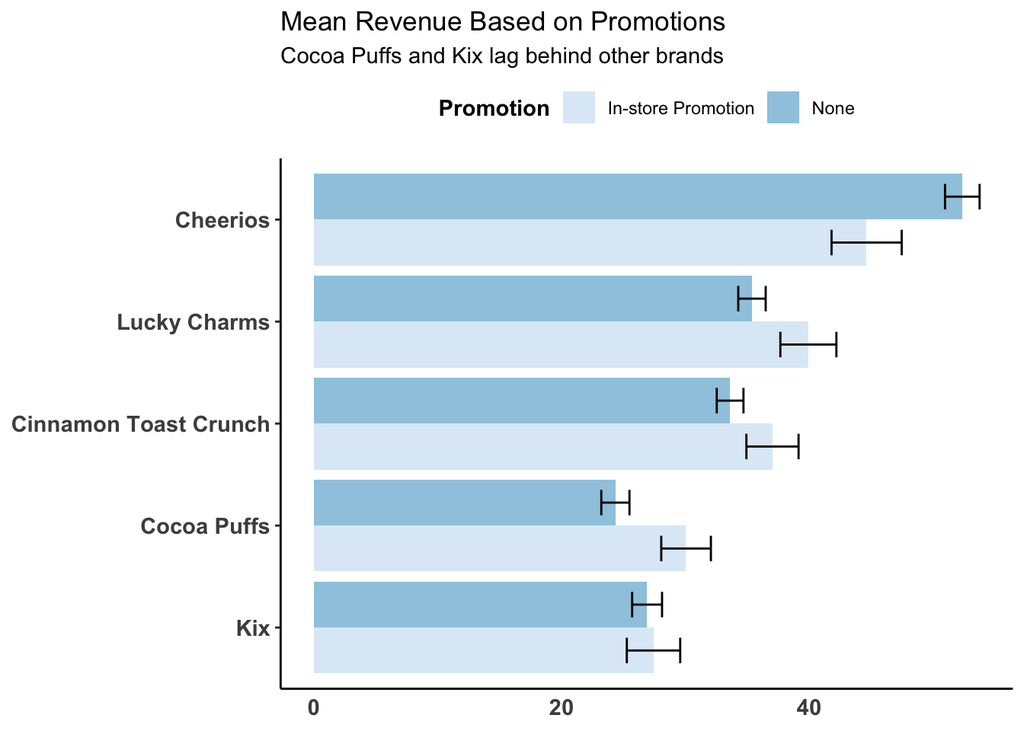

```r
#Graphing mean promotional revenue across General Mill branded cereals.
# 90% CI, get z-value for upper tail, use .95 since is one sided
z <- qnorm(.95)

# Incorporate CI into bar graph of means
mtp_gm %>%
  mutate(promo = if_else(promo == "0", "None", "In-store Promotion")) %>%
  group_by(cereal, promo) %>%
  summarise(m = mean(revenue), sd = sd(revenue),
            n = n(), ci = z * sd/sqrt(n)) %>%
  ggplot(aes(x = reorder(cereal, m), y = m, fill = promo)) +
  geom_bar(stat = "identity", position = "dodge") +
  geom_errorbar(aes(ymin = m - ci, ymax = m + ci),
                width = 0.5, position = position_dodge(0.9)) +
  coord_flip() +
  theme_classic() +
  xlab("") +
  labs(fill = "Promotion") +
  theme(axis.text = element_text(face = "bold", size = 11),
        axis.ticks.x = element_blank(),
        axis.title.x = element_blank(),
        axis.title = element_blank(),
        legend.position = "top",
        legend.title = element_text(face = "bold")) +
  scale_fill_brewer() +
  ggtitle("Mean Revenue Based on Promotions",
          subtitle = "Cocoa Puffs and Kix lag behind other brands")
```

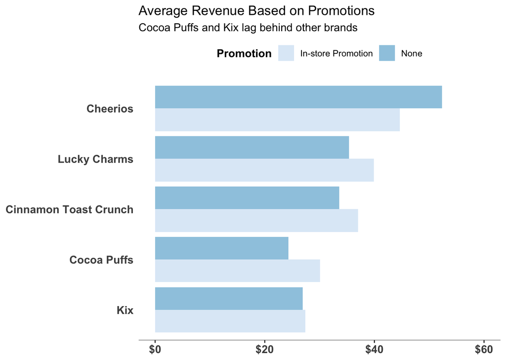

```r
mtp_g2 <- mtp_gm %>%
  mutate(promo = if_else(promo == "0", "None", "In-store Promotion")) %>%
  group_by(cereal, promo) %>%
  summarise(m = mean(revenue), sd = sd(revenue),
            n = n(), ci = z * sd/sqrt(n)) %>%
  ggplot(aes(x = reorder(cereal, m), y = m, fill = promo)) +
  geom_bar(stat = "identity", position = "dodge") +
  coord_flip() +
  scale_y_continuous(limits = c(0, 60),
                     labels = dollar_format(prefix = "$")) +
  theme_classic() +
  labs(fill = "Promotion") +
  theme(axis.text = element_text(face = "bold", size = 11),
        axis.title = element_blank(),
        axis.ticks.y = element_blank(),
        axis.line.y = element_blank(),
        axis.line.x = element_line(colour = "grey"),
        legend.position = "top",
        legend.title = element_text(face = "bold")) +
  scale_fill_brewer() +
  ggtitle("Average Revenue Based on Promotions",
          subtitle = "Cocoa Puffs and Kix lag behind other brands")

mtp_g2
```

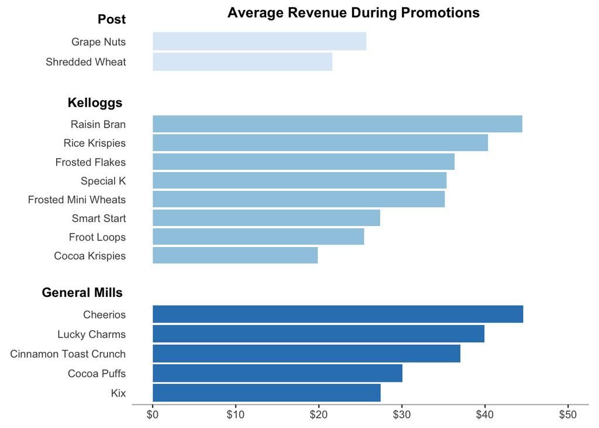

```r
ggsave("mtp_g2.png", plot = mtp_g2)
gPost <- mtp_hyp1 %>%
    filter(company == "Post") %>%
    group_by(company, cereal) %>%
    summarise(m = mean(revenue), sd = sd(revenue),
            n = n(), ci = z * sd/sqrt(n)) %>%
    ggplot(aes(x = reorder(cereal, m), y = m)) +
    geom_bar(stat = "identity", position = "dodge",
             fill = "#deebf7") +
    coord_flip() +
  scale_y_continuous(limits = c(0, 50)) +
    theme_classic() +
    theme(axis.line.y = element_blank(),
          axis.ticks.y = element_blank(),
          axis.line.x = element_blank(),
          axis.ticks.x = element_blank(),
          axis.title = element_blank(),
          axis.text.y = element_text(size = 9),
          axis.text.x = element_blank()) +
    ggtitle("Post") +
  theme(plot.title = element_text(hjust = -0.08,
                                  vjust = -0.30,
                                  colour = "black",
                                  face = "bold",
                                  size = 11),
        plot.margin = unit(c(0.3,0.3,0.3,0.3), "cm"))

gKelloggs <- mtp_hyp1 %>%
    filter(company == "Kelloggs") %>%
    group_by(company, cereal) %>%
    summarise(m = mean(revenue), sd = sd(revenue),
            n = n(), ci = z * sd/sqrt(n)) %>%
    ggplot(aes(x = reorder(cereal, m), y = m)) +
    geom_bar(stat = "identity", position = "dodge",
             fill = "#9ecae1") +
    coord_flip() +
  scale_y_continuous(limits = c(0, 50)) +
    theme_classic() +
    theme(axis.line.y = element_blank(),
          axis.ticks.y = element_blank(),
          axis.line.x = element_blank(),
          axis.ticks.x = element_blank(),
          axis.title = element_blank(),
          axis.text.y = element_text(size = 9),
          axis.text.x = element_blank()) +
  ggtitle("Kelloggs") +
  theme(plot.title = element_text(hjust = -0.16,
                                  vjust = -0.16,
                                  colour = "black",
                                  face = "bold",
                                  size = 11),
        plot.margin = unit(c(0.2,0.2,0.2,0.2), "cm"))

gGMills <- mtp_hyp1 %>%
    filter(company == "General_Mills") %>%
    group_by(company, cereal) %>%
    summarise(m = mean(revenue), sd = sd(revenue),
            n = n(), ci = z * sd/sqrt(n)) %>%
    ggplot(aes(x = reorder(cereal, m), y = m)) +
    geom_bar(stat = "identity", position = "dodge", fill = "#3182bd") +
    coord_flip() +
  scale_y_continuous(limits = c(0, 50),
                     labels = dollar_format(prefix = "$")) +
    theme_classic() +
    theme(axis.line.y = element_blank(),
          axis.title = element_blank(),
          axis.ticks.y = element_blank(),
          axis.line.x = element_line(colour = "grey"),
          axis.text = element_text(size = 9),
          legend.position = "bottom") +
  ggtitle("General Mills") +
  theme(plot.title = element_text(hjust = -0.24,
                                  vjust = -0.24,
                                  colour = "black",
                                  face = "bold",
                                  size = 11),
        plot.margin = unit(c(0.2,0.2,0.2,0.2), "cm"))

mtp_g1 <- cowplot::plot_grid(gPost, gKelloggs, gGMills,
                   align = "v", nrow = 3,
                   rel_heights = c(0.23, 0.5, 0.4),
                   labels = "Average Revenue During Promotions",
                   label_size = 12,
                   hjust = -0.9,
                   vjust = 1.7)
mtp_g1
```

```r
ggsave("mtp_g1.png", plot = mtp_g1)
```

### 6.1.3 Conclusions to Question 1

Based on our analysis we can reliably say that General Mills’ current promotional strategy has the competitive advange in the market when looking at mean revenue. Although this finding is both economically and statistically significant there are also areas in which General Mills can refine and improve their promotional strategy. Upon further analysis we can see that the Cocoa Puffs and Kix brands are not performing as well as other brands in the General Mills family of brands. Cocoa Puffs and Kix both have significantly lower mean revenue and mean units per sale than any of the other brands. Why is this? Pricing may need to be changed, Kix has a very high average price per volume so their packaging may be too small and customers are not seeing it as a “good value” whether it is on promotion or not. Testing pricing or packaging with Kix during an in-store promotion would be a valuable opportunity to acquire sample data sets for future analysis. For Cocoa Puffs, promotions significantly improve thier numbers so increasing the number of promotions invovling Cocoa Puffs could yield better numbers for the brand moving forward.

## 6.2 Question 2: How effective is General Mills’ advertising strategy and how can we improve its revenue generating ability?

### 6.2.1 First we can examine if ads have any measurable affect on revenue or units sold.

```r
#Table for ad effectiveness across the whole market.
mtp %>%
  group_by(ad) %>%
  summarise(Count = n(),
  Average_Revenue = mean(revenue),
  Average_Price = mean(price),
  Average_Price_Vol = mean(price_volume),
  Average_Units = mean(units)) %>%
  arrange(desc(Average_Revenue)) %>%
  kable() %>%
  kable_styling(bootstrap_options = c("striped", "hover", "condensed", "responsive"))
```

| ad | Count | Average_Revenue | Average_Price | Average_Price_Vol | Average_Units |
| --- | --- | --- | --- | --- | --- |
| B | 1061 | 33.65694 | 3.155966 | 3.583920 | 11.268614 |
| A | 1456 | 33.13334 | 3.287328 | 3.596984 | 10.717720 |
| NONE | 19333 | 30.70731 | 3.832665 | 4.216988 | 8.270263 |

```r
#Table for just General Mills
mtp_gm %>%
  group_by(ad) %>%
  summarise(Count = n(),
  Average_Revenue = mean(revenue),
  Average_Price = mean(price),
  Average_Price_Vol = mean(price_volume),
  Average_Units = mean(units)) %>%
  arrange(desc(Average_Revenue)) %>%
  kable() %>%
  kable_styling(bootstrap_options = c("striped", "hover", "condensed", "responsive"))
```

| ad | Count | Average_Revenue | Average_Price | Average_Price_Vol | Average_Units |
| --- | --- | --- | --- | --- | --- |
| A | 442 | 37.65007 | 3.372376 | 4.051076 | 11.823529 |
| NONE | 6475 | 35.59291 | 3.925404 | 4.587407 | 9.351197 |
| B | 272 | 35.23559 | 3.128052 | 3.921082 | 11.919118 |

**Null Hypothesis: Revenue is the same whether they are running ads or not.**

```r
# Is revenue the same whether running an add or not?
t.test(mtp$revenue[mtp$ad == "NONE"], mtp$revenue[mtp$ad != "NONE"])
```

```
##
##  Welch Two Sample t-test
##
## data:  mtp$revenue[mtp$ad == "NONE"] and mtp$revenue[mtp$ad != "NONE"]
## t = -5.3565, df = 3308.9, p-value = 9.065e-08
## alternative hypothesis: true difference in means is not equal to 0
## 95 percent confidence interval:
##  -3.615554 -1.677934
## sample estimates:
## mean of x mean of y
##  30.70731  33.35406
```

```r
#
t.test(mtp_gm$revenue[mtp_gm$ad == "NONE"], mtp_gm$revenue[mtp_gm$ad != "NONE"])
```

```
##
##  Welch Two Sample t-test
##
## data:  mtp_gm$revenue[mtp_gm$ad == "NONE"] and mtp_gm$revenue[mtp_gm$ad != "NONE"]
## t = -1.1963, df = 920.69, p-value = 0.2319
## alternative hypothesis: true difference in means is not equal to 0
## 95 percent confidence interval:
##  -3.0032385  0.7285194
## sample estimates:
## mean of x mean of y
##  35.59291  36.73027
```

[figure not shown]

```r
# 90% CI, get z-value for upper tail, use .95 since is one sided
z <- qnorm(.95)

# Incorporate CI into bar graph of means
mtp %>%
  mutate(ad = if_else(ad == "A", "Big", if_else(ad == "B", "Medium/Small", "None"))) %>%
  group_by(company, ad) %>%
  summarise(m = mean(revenue), sd = sd(revenue),
            n = n(), ci = z * sd/sqrt(n)) %>%
  ggplot(aes(x = company, y = m, fill = ad)) +
  geom_bar(stat = "identity", position = "dodge") +
  geom_errorbar(aes(ymin = m - ci, ymax = m + ci),
                width = 0.5, position = position_dodge(0.9)) +
  theme_classic() +
  labs(fill = "Ad") +
  theme(axis.text = element_text(face = "bold", size = 11),
        axis.ticks.x = element_blank(),
        axis.title.x = element_blank(),
        axis.title = element_blank(),
        legend.position = "top",
        legend.title = element_text(face = "bold")) +
  scale_fill_brewer(palette = "Purples") +
  ggtitle("Mean Revenue Based on Ads",
          subtitle = "Running ads does not statistically effect revenue. ")
```

### 6.2.2 Next we can see if there is a difference in units when running an ad.

```r
# Are units the same whether running an ads or not?
t.test(mtp$units[mtp$ad == "NONE"], mtp$units[mtp$ad != "NONE"])
```

```
##
##  Welch Two Sample t-test
##
## data:  mtp$units[mtp$ad == "NONE"] and mtp$units[mtp$ad != "NONE"]
## t = -17.093, df = 3032.3, p-value < 2.2e-16
## alternative hypothesis: true difference in means is not equal to 0
## 95 percent confidence interval:
##  -2.987070 -2.372284
## sample estimates:
## mean of x mean of y
##  8.270263 10.949940
```

```r
# Are units the same whether running ads or not for General Mills?
t.test(mtp_gm$units[mtp_gm$ad == "NONE"], mtp_gm$units[mtp_gm$ad != "NONE"])
```

```
##
##  Welch Two Sample t-test
##
## data:  mtp_gm$units[mtp_gm$ad == "NONE"] and mtp_gm$units[mtp_gm$ad != "NONE"]
## t = -8.5544, df = 848.67, p-value < 2.2e-16
## alternative hypothesis: true difference in means is not equal to 0
## 95 percent confidence interval:
##  -3.084366 -1.933128
## sample estimates:
## mean of x mean of y
##  9.351197 11.859944
```

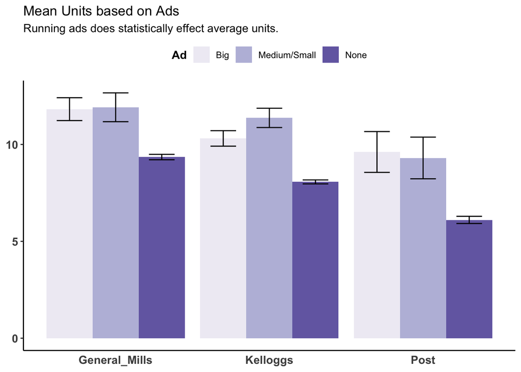

```r
# 90% CI, get z-value for upper tail, use .95 since is one sided
z <- qnorm(.95)

# Incorporate CI into bar graph of means
mtp %>%
  mutate(ad = if_else(ad == "A", "Big", if_else(ad == "B", "Medium/Small", "None"))) %>%
  group_by(company, ad) %>%
  summarise(m = mean(units), sd = sd(units),
            n = n(), ci = z * sd/sqrt(n)) %>%
  ggplot(aes(x = company, y = m, fill = ad)) +
  geom_bar(stat = "identity", position = "dodge") +
  geom_errorbar(aes(ymin = m - ci, ymax = m + ci),
                width = 0.5, position = position_dodge(0.9)) +
  theme_classic() +
  labs(fill = "Ad") +
  theme(axis.text = element_text(face = "bold", size = 11),
        axis.ticks.x = element_blank(),
        axis.title.x = element_blank(),
        axis.title = element_blank(),
        legend.position = "top",
        legend.title = element_text(face = "bold")) +
  scale_fill_brewer(palette = "Purples") +
  ggtitle("Mean Units based on Ads",
          subtitle = "Running ads does statistically effect average units. ")
```

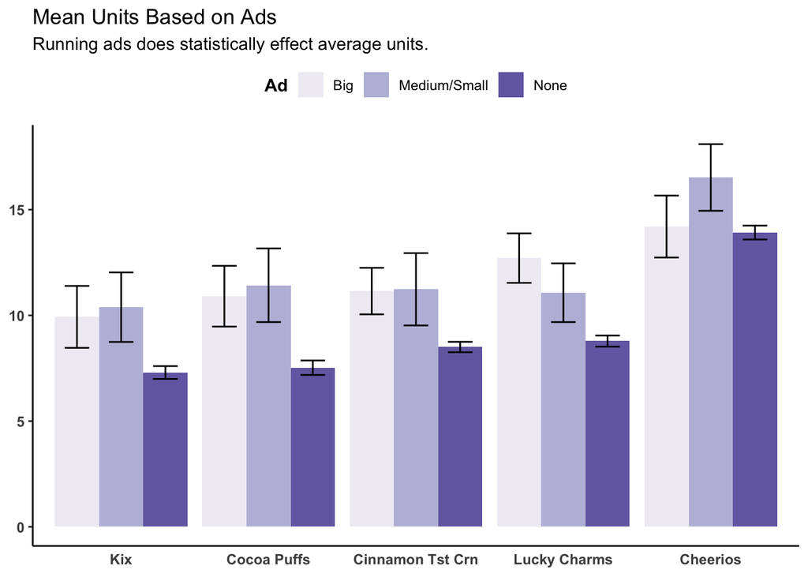

```r
mtp_gm %>%
  mutate(ad = if_else(ad == "A", "Big", if_else(ad == "B", "Medium/Small", "None")),
         cereal = str_replace(cereal, "Toast Crunch", "Tst Crn")) %>%
  group_by(cereal, ad) %>%
  summarise(m = mean(units), sd = sd(units),
            n = n(), ci = z * sd/sqrt(n)) %>%
  ggplot(aes(x = reorder(cereal,m), y = m, fill = ad)) +
  geom_bar(stat = "identity", position = "dodge") +
  geom_errorbar(aes(ymin = m - ci, ymax = m + ci),
                width = 0.5, position = position_dodge(0.9)) +
  theme_classic() +
  labs(fill = "Ad") +
  theme(axis.text = element_text(face = "bold", size = 9),
        axis.ticks.x = element_blank(),
        axis.title.x = element_blank(),
        axis.title = element_blank(),
        legend.position = "top",
        legend.title = element_text(face = "bold")) +
  scale_fill_brewer(palette = "Purples") +
  ggtitle("Mean Units Based on Ads",
          subtitle = "Running ads does statistically effect average units. ")
```

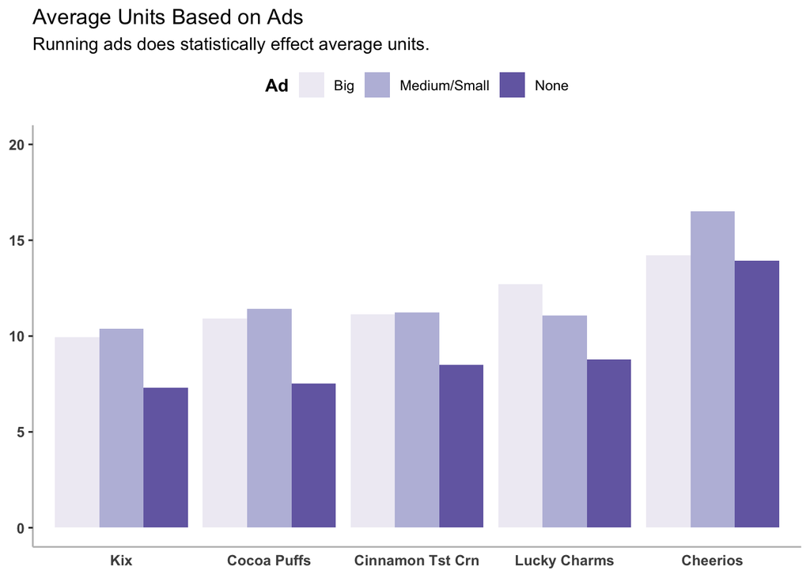

```r
#Graph for Memo finding 2.
mtp_g3 <- mtp_gm %>%
  mutate(ad = if_else(ad == "A", "Big", if_else(ad == "B", "Medium/Small", "None")),
         cereal = str_replace(cereal, "Toast Crunch", "Tst Crn")) %>%
  group_by(cereal, ad) %>%
  summarise(m = mean(units), sd = sd(units),
            n = n(), ci = z * sd/sqrt(n)) %>%
  ggplot(aes(x = reorder(cereal,m), y = m, fill = ad)) +
  geom_bar(stat = "identity", position = "dodge") +
  theme_classic() +
  scale_y_continuous(limits = c(0, 20)) +
  labs(fill = "Ad") +
  theme(axis.text = element_text(face = "bold", size = 9),
        axis.ticks.x = element_blank(),
        axis.title.x = element_blank(),
        axis.title = element_blank(),
        axis.line = element_line(colour = "grey"),
        legend.position = "top",
        legend.title = element_text(face = "bold")) +
  scale_fill_brewer(palette = "Purples") +
  ggtitle("Average Units Based on Ads",
          subtitle = "Running ads does statistically effect average units. ")

mtp_g3
```

```r
#Save graph for Memo
ggsave("mtp_g3.png", plot = mtp_g3)
```

### 6.2.3 Conclusion to Qustion 2

Based on our analysis of the effectiveness of advertising on Genereal Mills brands we found that there is no statistical difference in effect on revenue when using ads vs. when not using them. This has interesting implications because we can show that advertising does have an effect on units– increasing them by a statistically significant amount. Since units and revenue are highly positively correlated we would think that these increases in units would lead to an increase in revenue. However, this is not the case. This is probably due to pricing and running ads concurrently with promotions, we recommend trying to increase the amount of ads run without promotions and revist to see if the ad campaigns are successful at increasing revenue.

# 7 Multiple regression with log(earnings) as the dependent variable.

```r
mod_all <- lm(log(revenue) ~ cereal + ad + promo + units, data = mtp)

# Review output
summary(mod_all)
```

```
##
## Call:
## lm(formula = log(revenue) ~ cereal + ad + promo + units, data = mtp)
##
## Residuals:
##     Min      1Q  Median      3Q     Max
## -3.1094 -0.2343  0.1196  0.3422  1.3105
##
## Coefficients:
##                               Estimate Std. Error t value Pr(>|t|)
## (Intercept)                  2.0388607  0.0200546 101.665  < 2e-16 ***
## cerealCinnamon Toast Crunch  0.1502385  0.0174024   8.633  < 2e-16 ***
## cerealCocoa Krispies        -0.1639127  0.0214763  -7.632 2.40e-14 ***
## cerealCocoa Puffs           -0.0330369  0.0202816  -1.629 0.103346
## cerealFroot Loops           -0.1171689  0.0170964  -6.853 7.40e-12 ***
## cerealFrosted Flakes         0.0529726  0.0165946   3.192 0.001414 **
## cerealFrosted Mini Wheats    0.0348886  0.0179725   1.941 0.052244 .
## cerealGrape Nuts             0.0673600  0.0191111   3.525 0.000425 ***
## cerealKix                    0.0043281  0.0194050   0.223 0.823506
## cerealLucky Charms           0.2068987  0.0177202  11.676  < 2e-16 ***
## cerealRaisin Bran            0.1414303  0.0189108   7.479 7.78e-14 ***
## cerealRice Krispies          0.0602233  0.0183032   3.290 0.001002 **
## cerealShredded Wheat        -0.1160513  0.0196721  -5.899 3.70e-09 ***
## cerealSmart Start            0.0084524  0.0199233   0.424 0.671390
## cerealSpecial K              0.1510224  0.0185747   8.131 4.50e-16 ***
## adB                         -0.0285649  0.0197753  -1.444 0.148621
## adNONE                       0.0558646  0.0137172   4.073 4.67e-05 ***
## promo1                      -0.2446872  0.0088197 -27.743  < 2e-16 ***
## units                        0.1166259  0.0005355 217.784  < 2e-16 ***
## ---
## Signif. codes:  0 '***' 0.001 '**' 0.01 '*' 0.05 '.' 0.1 ' ' 1
##
## Residual standard error: 0.4893 on 21831 degrees of freedom
## Multiple R-squared:  0.7225, Adjusted R-squared:  0.7222
## F-statistic:  3157 on 18 and 21831 DF,  p-value: < 2.2e-16
```

```r
mtp_gm <- mtp %>%
  filter(company == "General_Mills")

mod_gm <- lm(log(revenue) ~ cereal + ad + promo + units, data = mtp_gm)

# Review output
summary(mod_gm)
```

```
##
## Call:
## lm(formula = log(revenue) ~ cereal + ad + promo + units, data = mtp_gm)
##
## Residuals:
##      Min       1Q   Median       3Q      Max
## -2.79272 -0.22495  0.09825  0.33056  0.99198
##
## Coefficients:
##                               Estimate Std. Error t value Pr(>|t|)
## (Intercept)                  2.1137182  0.0293506  72.016  < 2e-16 ***
## cerealCinnamon Toast Crunch  0.1249400  0.0172650   7.237 5.08e-13 ***
## cerealCocoa Puffs           -0.0581981  0.0201915  -2.882  0.00396 **
## cerealKix                   -0.0266639  0.0193451  -1.378  0.16815
## cerealLucky Charms           0.1845420  0.0175309  10.527  < 2e-16 ***
## adB                         -0.0134775  0.0365775  -0.368  0.71254
## adNONE                       0.0571919  0.0240182   2.381  0.01728 *
## promo1                      -0.2947358  0.0158009 -18.653  < 2e-16 ***
## units                        0.1116984  0.0008752 127.633  < 2e-16 ***
## ---
## Signif. codes:  0 '***' 0.001 '**' 0.01 '*' 0.05 '.' 0.1 ' ' 1
##
## Residual standard error: 0.4738 on 7180 degrees of freedom
## Multiple R-squared:  0.722,  Adjusted R-squared:  0.7217
## F-statistic:  2331 on 8 and 7180 DF,  p-value: < 2.2e-16
```

Note: A regression analysis was not used for our analysis but is included here to give a deeper understanding of the data & dynamics at play, price was excluded to limit endogenous variable bias.